# Part I - (Loan Data from Prosper )

## by (Sameera Najjar)

### The dataset contains loan data from Prosper, a peer-to-peer lending platform, with 113,937 loans and 81 variables. These variables include details like loan amount, borrower rate, loan status, borrower income, and more. The data can be used to analyze various factors related to loan performance and borrower characteristics.

## Preliminary Wrangling

```python
# import all packages and set plots to be embedded inline
import numpy as np
import pandas as pd
import matplotlib.pyplot as plt
import seaborn as sns
```

```python
# Load the dataset to examine its properties
loan_data = pd.read_csv('prosperLoanData.csv')
```

```python
# Display basic information about the dataset
loan_data.info()
```

```
<class 'pandas.core.frame.DataFrame'>
RangeIndex: 113937 entries, 0 to 113936
Data columns (total 81 columns):
 #   Column                               Non-Null Count   Dtype
---  ------                               --------------   -----
 0   ListingKey                           113937 non-null  object
 1   ListingNumber                        113937 non-null  int64
 2   ListingCreationDate                  113937 non-null  object
 3   CreditGrade                          28953 non-null   object
 4   Term                                 113937 non-null  int64
 5   LoanStatus                           113937 non-null  object
 6   ClosedDate                           55089 non-null   object
 7   BorrowerAPR                          113912 non-null  float64
 8   BorrowerRate                         113937 non-null  float64
 9   LenderYield                          113937 non-null  float64
```

[output cut: 73 more lines]

```python
loan_data.head()
```

|  | ListingKey | ListingNumber | ListingCreationDate | CreditGrade | Term | LoanStatus | ClosedDate | BorrowerAPR | BorrowerRate | LenderYield | ... | LP_ServiceFees | LP_CollectionFees | LP_GrossPrincipalLoss | LP_NetPrincipalLoss | LP_NonPrincipalRecoverypayments | PercentFunded | Recommendations | InvestmentFromFriendsCount | InvestmentFromFriendsAmount | Investors |
| --- | --- | --- | --- | --- | --- | --- | --- | --- | --- | --- | --- | --- | --- | --- | --- | --- | --- | --- | --- | --- | --- |
| 0 | 1021339766868145413AB3B | 193129 | 2007-08-26 19:09:29.263000000 | C | 36 | Completed | 2009-08-14 00:00:00 | 0.16516 | 0.1580 | 0.1380 | ... | -133.18 | 0.0 | 0.0 | 0.0 | 0.0 | 1.0 | 0 | 0 | 0.0 | 258 |
| 1 | 10273602499503308B223C1 | 1209647 | 2014-02-27 08:28:07.900000000 | NaN | 36 | Current | NaN | 0.12016 | 0.0920 | 0.0820 | ... | 0.00 | 0.0 | 0.0 | 0.0 | 0.0 | 1.0 | 0 | 0 | 0.0 | 1 |
| 2 | 0EE9337825851032864889A | 81716 | 2007-01-05 15:00:47.090000000 | HR | 36 | Completed | 2009-12-17 00:00:00 | 0.28269 | 0.2750 | 0.2400 | ... | -24.20 | 0.0 | 0.0 | 0.0 | 0.0 | 1.0 | 0 | 0 | 0.0 | 41 |
| 3 | 0EF5356002482715299901A | 658116 | 2012-10-22 11:02:35.010000000 | NaN | 36 | Current | NaN | 0.12528 | 0.0974 | 0.0874 | ... | -108.01 | 0.0 | 0.0 | 0.0 | 0.0 | 1.0 | 0 | 0 | 0.0 | 158 |
| 4 | 0F023589499656230C5E3E2 | 909464 | 2013-09-14 18:38:39.097000000 | NaN | 36 | Current | NaN | 0.24614 | 0.2085 | 0.1985 | ... | -60.27 | 0.0 | 0.0 | 0.0 | 0.0 | 1.0 | 0 | 0 | 0.0 | 20 |

5 rows × 81 columns

### What is the structure of your dataset?

> The dataset has 113,937 entries and 81 columns. It includes a mix of numeric, categorical, and date variables. Some columns have missing values, such as CreditGrade and ClosedDate.

### What is/are the main feature(s) of interest in your dataset?

> The main features of interest could be LoanStatus, BorrowerAPR, and BorrowerRate, as these directly relate to loan performance and cost to the borrower.

### What features in the dataset do you think will help support your investigation into your feature(s) of interest?

> Features like CreditGrade, ProsperRating (Alpha), ProsperScore, EmploymentStatus, DebtToIncomeRatio, and BorrowerState are likely to influence LoanStatus and borrower rates.

## Univariate Exploration

### 1. Distribution of LoanStatus

#### I start by looking at the distribution of the LoanStatus, which indicates the current status of the loans.

```python
# Defining the order of LoanStatus
loan_status_order = [
    'Current', 'Completed', 'FinalPaymentInProgress',
    'Past Due (1-15 days)', 'Past Due (16-30 days)', 'Past Due (31-60 days)',
    'Past Due (61-90 days)', 'Past Due (91-120 days)', 'Past Due (>120 days)',
    'Chargedoff', 'Defaulted'
]
```

```python
# Converting LoanStatus to a categorical variable with the specified order
loan_data['LoanStatus'] = pd.Categorical(loan_data['LoanStatus'], categories=loan_status_order, ordered=True)
```

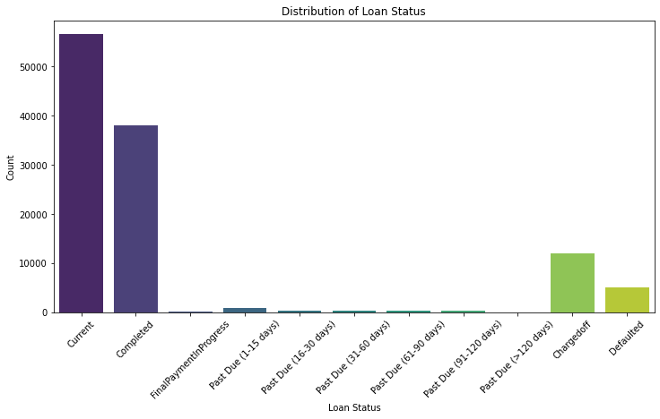

```python
# Plotting the distribution of LoanStatus
plt.figure(figsize=(12, 6))
sns.countplot(data=loan_data, x='LoanStatus', order=loan_status_order, palette='viridis')
plt.title('Distribution of Loan Status')
plt.xticks(rotation=45)
plt.ylabel('Count')
plt.xlabel('Loan Status')
```

### Observations:

#### The most common loan statuses are "Current" and "Completed."

##### There are also a significant number of loans that are "Chargedoff," indicating loans that have defaulted.

### 2. Distribution of BorrowerAPR

#### examine the distribution of the BorrowerAPR, which is the annual percentage rate the borrower pays.

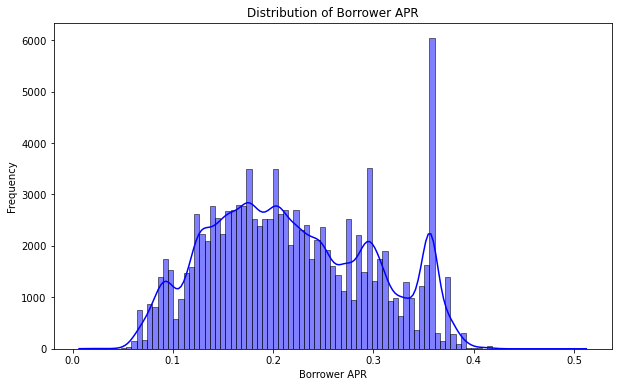

```python
# Plotting the distribution of BorrowerAPR
plt.figure(figsize=(10, 6))
sns.histplot(loan_data['BorrowerAPR'].dropna(), kde=True, color='blue')
plt.title('Distribution of Borrower APR')
plt.xlabel('Borrower APR')
plt.ylabel('Frequency')
```

### Observations:

##### There are a few loans with much higher APRs, indicating potential outliers.

### 3. Distribution of ProsperRating (Alpha)

#### Let's also explore the distribution of ProsperRating (Alpha), which is an assigned credit rating for borrowers.

```python
# Setting up the proper order for 'ProsperRating (Alpha)'
prosper_rating_order = ['AA', 'A', 'B', 'C', 'D', 'E', 'HR']
loan_data['ProsperRating (Alpha)'] = pd.Categorical(loan_data['ProsperRating (Alpha)'], categories=prosper_rating_order, ordered=True)
```

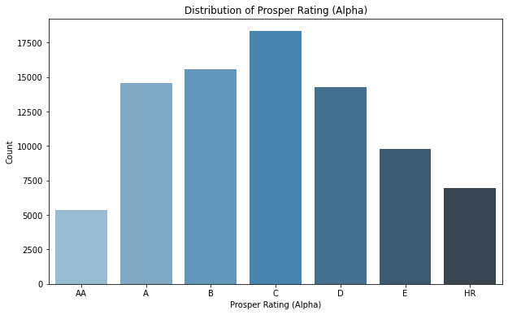

```python
plt.figure(figsize=(10, 6))
sns.countplot(data=loan_data, x='ProsperRating (Alpha)', palette='Blues_d', order=prosper_rating_order)
plt.title('Distribution of Prosper Rating (Alpha)')
plt.xlabel('Prosper Rating (Alpha)')
plt.ylabel('Count')
```

### Discuss the distribution(s) of your variable(s) of interest. Were there any unusual points? Did you need to perform any transformations?

> The Distribution of the LoanStatus chart illustrates that most loans are "Current" or have been completed, whereas a non-trivial amount has defaulted ("Chargedoff").

> ProsperRating (Alpha) distribution centered around mid-level ratings that would show both high-risk and low-risk borrowers.

### Of the features you investigated, were there any unusual distributions? Did you perform any operations on the data to tidy, adjust, or change the form of the data? If so, why did you do this?

> The BorrowerAPR distribution leaves open some ex-outlier possibilities. This however did not performed any operation till yet in this stage. As a part of bivariate or multivarite analysis, we might have to treat outliers in the raw data itself through transformations.

## Bivariate Exploration

### 1. Relationship between BorrowerAPR and ProsperRating (Alpha)

#### examining how the BorrowerAPR varies with the ProsperRating (Alpha).

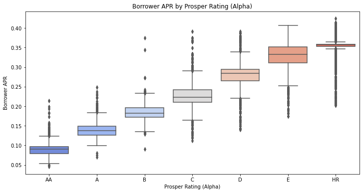

```python
# Plotting the relationship between BorrowerAPR and ProsperRating (Alpha)
plt.figure(figsize=(12, 6))
sns.boxplot(data=loan_data, x='ProsperRating (Alpha)', y='BorrowerAPR', palette='coolwarm')
plt.title('Borrower APR by Prosper Rating (Alpha)')
plt.ylabel('Borrower APR')
plt.xlabel('Prosper Rating (Alpha)')
```

### Observations:

##### Borrowers with higher Prosper Ratings (AA, A) tend to have lower APRs, indicating that they are considered lower risk.

##### Borrowers with lower Prosper Ratings (D, HR) have higher APRs, reflecting their higher risk status.

##### There is a clear inverse relationship between the Prosper Rating and the Borrower APR.

### 2. Relationship between LoanStatus and EmploymentStatus

#### how the LoanStatus varies across different EmploymentStatus categories.

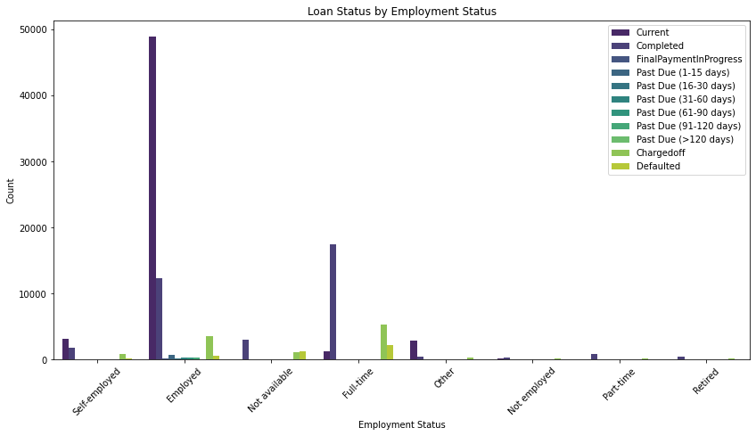

```python
# Plotting the relationship between LoanStatus and EmploymentStatus
plt.figure(figsize=(14, 7))
sns.countplot(data=loan_data, x='EmploymentStatus', hue='LoanStatus', palette='viridis')
plt.title('Loan Status by Employment Status')
plt.ylabel('Count')
plt.xlabel('Employment Status')
plt.xticks(rotation=45)
plt.legend(loc='upper right')
```

### Observations:

##### Most loans belong to borrowers who are Employed

##### The majority of loans in the Employed category are either "Current" or "Completed."

##### The distribution for other employment statuses like Self-employed or Not employed shows a higher proportion of loans in default ("Chargedoff").

### 3. Relationship between DebtToIncomeRatio and LoanStatus

#### analyze the relationship between DebtToIncomeRatio and LoanStatus.

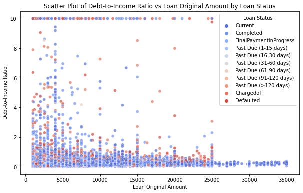

```python
plt.figure(figsize=(10, 6))
sns.scatterplot(data=loan_data, x='LoanOriginalAmount', y='DebtToIncomeRatio', hue='LoanStatus', palette='coolwarm', alpha=0.7)
plt.title('Scatter Plot of Debt-to-Income Ratio vs Loan Original Amount by Loan Status')
plt.xlabel('Loan Original Amount')
plt.ylabel('Debt-to-Income Ratio')
plt.legend(title='Loan Status', loc='upper right')
```

### Observations:

###### The fact that there is a large amount of overlap among the various loan statuses suggests that loan performance cannot be strongly predicted by the debt-to-income ratio on its own. It's possible that other elements including the borrower's income, work status, and credit history are also significant.

### 4.Correlation Matrix of Numeric Variables

```python
# Select relevant numeric variables for the heatmap
selected_columns = ['BorrowerAPR', 'LoanOriginalAmount', 'DebtToIncomeRatio', 'BorrowerRate', 'ProsperScore']
```

```python
# Calculate the correlation matrix for the selected numeric variables
selected_corr_matrix = loan_data[selected_columns].corr()
```

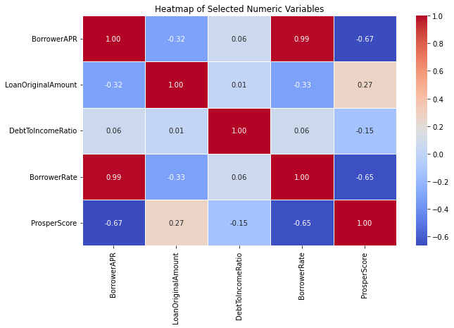

```python
# Plot the heatmap
plt.figure(figsize=(10, 6))
sns.heatmap(selected_corr_matrix, annot=True, fmt=".2f", cmap='coolwarm', linewidths=0.5)
plt.title('Heatmap of Selected Numeric Variables')
plt.show()
```

## Multivariate Exploration

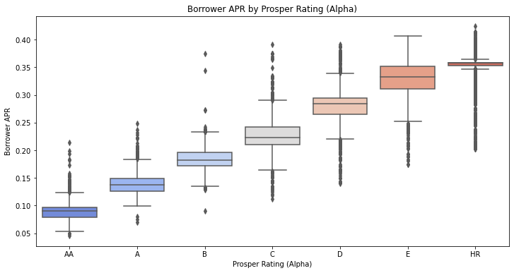

```python
# Plotting BorrowerAPR against ProsperRating (Alpha) and LoanStatus
# Corrected plotting for BorrowerAPR vs. ProsperRating (Alpha)
plt.figure(figsize=(12, 6))
sns.boxplot(data=loan_data, x='ProsperRating (Alpha)', y='BorrowerAPR', palette='coolwarm')
plt.title('Borrower APR by Prosper Rating (Alpha)')
plt.ylabel('Borrower APR')
plt.xlabel('Prosper Rating (Alpha)')
```

### 2. Relationship between DebtToIncomeRatio, ProsperRating (Alpha), and LoanStatus

##### how the DebtToIncomeRatio interacts with ProsperRating (Alpha) and LoanStatus.

```python
# Define the correct order for the ProsperRating (Alpha) variable
prosper_rating_order = ['HR', 'E', 'D', 'C', 'B', 'A', 'AA']
```

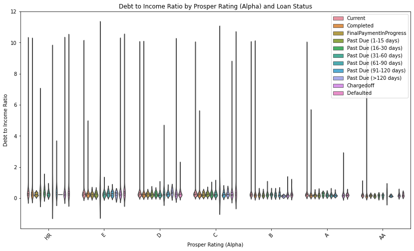

```python
# Set up the figure
plt.figure(figsize=(14, 8))
# Create the violin plot
sns.violinplot( data=loan_data, x='ProsperRating (Alpha)', y='DebtToIncomeRatio', hue='LoanStatus', inner="quart", order=prosper_rating_order)
# Add title and labels
plt.title('Debt to Income Ratio by Prosper Rating (Alpha) and Loan Status')
plt.ylabel('Debt to Income Ratio')
plt.xlabel('Prosper Rating (Alpha)')
# Rotate x-ticks for better readability
plt.xticks(rotation=45)
# Adjust legend position
plt.legend(loc='upper right')
```

### 3. Relationship between LoanOriginalAmount, BorrowerAPR, and ProsperRating (Alpha)

#### relationship between the original loan amount, BorrowerAPR, and ProsperRating (Alpha) to see how loan size impacts the APR across different credit ratings.

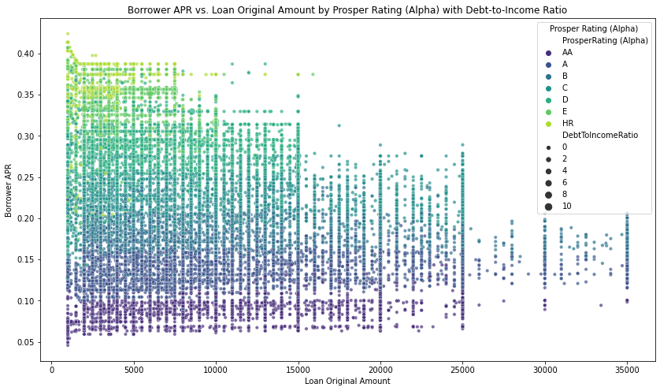

```python
### Scatterplot with Multiple Encodings
plt.figure(figsize=(14, 8))
sns.scatterplot(data=loan_data, x='LoanOriginalAmount', y='BorrowerAPR', hue='ProsperRating (Alpha)', size='DebtToIncomeRatio', palette='viridis', alpha=0.7)
plt.title('Borrower APR vs. Loan Original Amount by Prosper Rating (Alpha) with Debt-to-Income Ratio')
plt.xlabel('Loan Original Amount')
plt.ylabel('Borrower APR')
plt.legend(title='Prosper Rating (Alpha)', loc='upper right')
```

### Observations:

##### Higher loan amounts are often associated with lower APRs, particularly for higher-rated borrowers (AA, A).

##### Lower-rated borrowers (D, E, HR) not only tend to have higher APRs but also show a wider spread in APR for similar loan amounts, indicating less favorable terms.

##### There is a clear separation between high and low ratings, with higher-rated borrowers getting better terms across the board.

### 4.Relationship between BorrowerAPR, LoanStatus, and ProsperRating (Alpha)

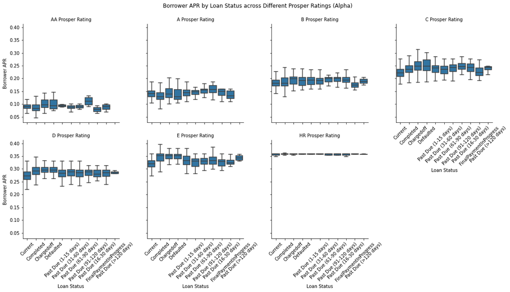

```python
# Facet plot of BorrowerAPR by LoanStatus, separated by ProsperRating (Alpha)
g = sns.FacetGrid(loan_data, col='ProsperRating (Alpha)', col_wrap=4, height=4, sharey=True, palette='Set3')
g.map(sns.boxplot, 'LoanStatus', 'BorrowerAPR', order=loan_data['LoanStatus'].value_counts().index, showfliers=False)
g.set_titles(col_template="{col_name} Prosper Rating")
g.set_axis_labels("Loan Status", "Borrower APR")
g.set_xticklabels(rotation=45)
plt.subplots_adjust(top=0.9)
g.fig.suptitle('Borrower APR by Loan Status across Different Prosper Ratings (Alpha)')
```

### Were there any interesting or surprising interactions between features?

> Interaction between ProsperRating (Alpha) and LoanStatus: Even among borrowers with good ratings, those whose loans were charged off had somewhat higher annual percentage rates (APRs). This suggests that even small increases in risk (as judged by lenders) can have a big influence on loan terms. Impact of Debt-to-Income Ratio: The impact of the debt-to-income ratio was more noticeable for borrowers with worse ratings, which may indicate that they are subject to more scrutiny or have less wiggle room when it comes to loan terms.

## Conclusions

> Significant relationships between credit ratings, loan statuses, and financial measures including APR and debt-to-income ratio were found through this multivariate investigation. The results underline the importance of credit rating in dictating loan terms and conditions, but they also show the complex ways in which financial burdens—such as debt-to-income ratios—affect lending behavior and risk. These revelations may be vital for lenders evaluating risk as well as for customers comprehending how their credit histories affect the cost and accessibility of loans.